# Stat 313 - First Synchronous Meeting!

September 23, 2020

## Welcome to Our Course

**Group Norms:**

- Zero tolerance for: racism, sexism, homophobia, transphobia, ageism, ableism
- Be the expert of your own experience – Use “I” statements
- Respect one another
- Intent and impact *both* matter
- Non-judgmental
- Take space, make space – Share the air
- Embrace discomfort
- Make decisions by consensus

## What is Statistics?

> Scientists seek to answer questions using rigorous methods and careful observations. These observations – collected from the likes of field notes, surveys, and experiments – form the backbone of a statistical investigation and are called data.

> Statistics is the study of how best to collect, analyze, and draw conclusions from data.

> *Introduction to Modern Statistics*

## What Statistics Is To Me

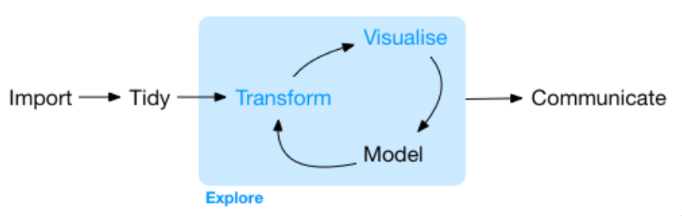

## Data

Gender stereotypes in 5-7 year old children

| subject | sex | age | trait | target | stereotype | high_achieve_caution |
| --- | --- | --- | --- | --- | --- | --- |
| 25 | male | 6 | nice | children | 0.75 | 1.00 |
| 7 | female | 6 | nice | adults | 0.75 | 0.50 |
| 3 | male | 7 | smart | adults | 0.25 | 0.25 |
| 70 | male | 5 | smart | adults | 0.50 | 1.00 |
| 11 | male | 6 | smart | adults | 1.00 | 0.75 |
| 5 | male | 5 | nice | adults | 0.25 | 0.75 |

## In Every Context

Heights of NBA players from the 2008-2009 season

| last_name | first_name | h_meters | h_in |
| --- | --- | --- | --- |
| West | David | 2.06 | 81 |
| Biedrins | Andris | 2.11 | 83 |
| Garnett | Kevin | 2.11 | 83 |
| Cardinal | Brian | 2.03 | 80 |
| Hunter | Othello | 2.03 | 80 |
| Graham | Stephen | 1.98 | 78 |

## You Could Imagine

Voting history of the United Nations General Assembly

| rcid | country | country_code | vote |
| --- | --- | --- | --- |
| 3798 | Thailand | TH | yes |
| 2171 | Yugoslavia | YU | yes |
| 4224 | Kuwait | KW | yes |
| 4101 | Indonesia | ID | abstain |
| 3973 | Marshall Islands | MH | yes |
| 4306 | Sweden | SE | yes |

## Types of Variables

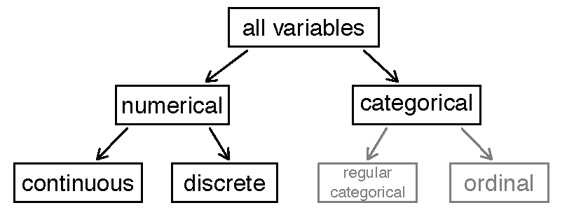

## Data Types in `R`

```r
loan50
```

```
## # A tibble: 50 x 6
##    state  term ownership income verified_income has_second_income
##    <fct> <dbl> <fct>      <dbl> <fct>           <lgl>
##  1 NJ       60 rent       59000 Not Verified    FALSE
##  2 CA       36 rent       60000 Not Verified    FALSE
##  3 SC       36 mortgage   75000 Verified        FALSE
##  4 CA       36 rent       75000 Not Verified    FALSE
##  5 OH       60 mortgage  254000 Not Verified    FALSE
##  6 IN       36 mortgage   67000 Source Verified FALSE
##  7 NY       36 rent       28800 Source Verified FALSE
##  8 MO       36 mortgage   80000 Not Verified    FALSE
##  9 FL       60 rent       34000 Not Verified    FALSE
## 10 FL       60 mortgage   80000 Source Verified TRUE
## # … with 40 more rows
```

## 90 Second Writing Exercise

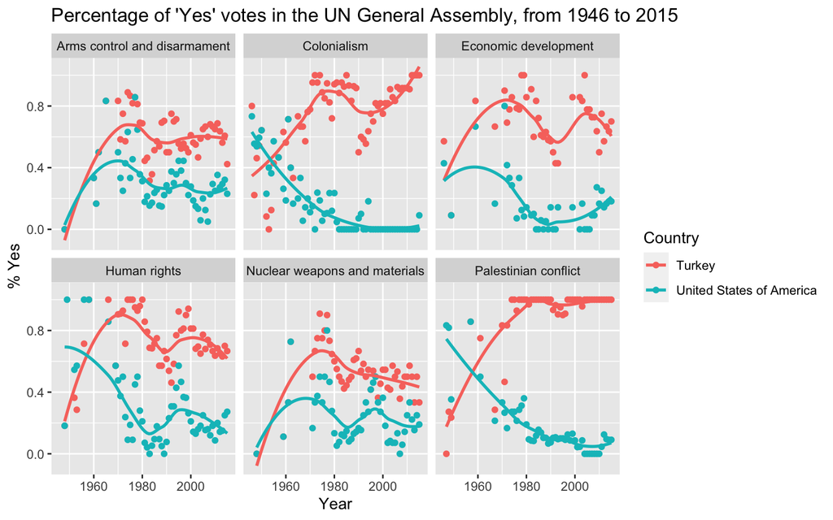

## Sampling Strategies

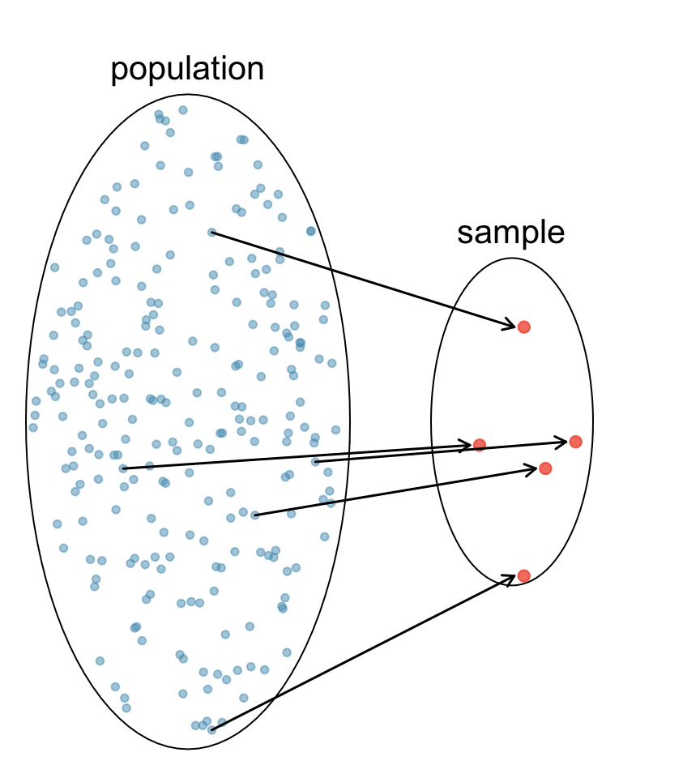

- Simple random sample
- Stratified random sample
- Cluster sample
- Multistage sample

## Types of Studies

**Experiment**

- randomization
- replication
- controlling
- blocking

**Observational Study**

- collect data in a way that does not directly interfere with how the data arise

## Relationships Between Variables

explanatory variable \(\rightarrow\) *might affect* \(\rightarrow\) response variable

- If two variables are not associated, then they are said to be **independent**.
- If two variables are associated, then they are said to be **dependent**.

association \(\neq\) causation

**What do you need to say that the explanatory variable **causes** a change in the response variable?**

## Group Exercise

The following scatterplot was created as part of a study evaluating the relationship between estimated life expectancy at birth (as of 2014) and percentage of internet users (as of 2009) in 208 countries for which such data were available.

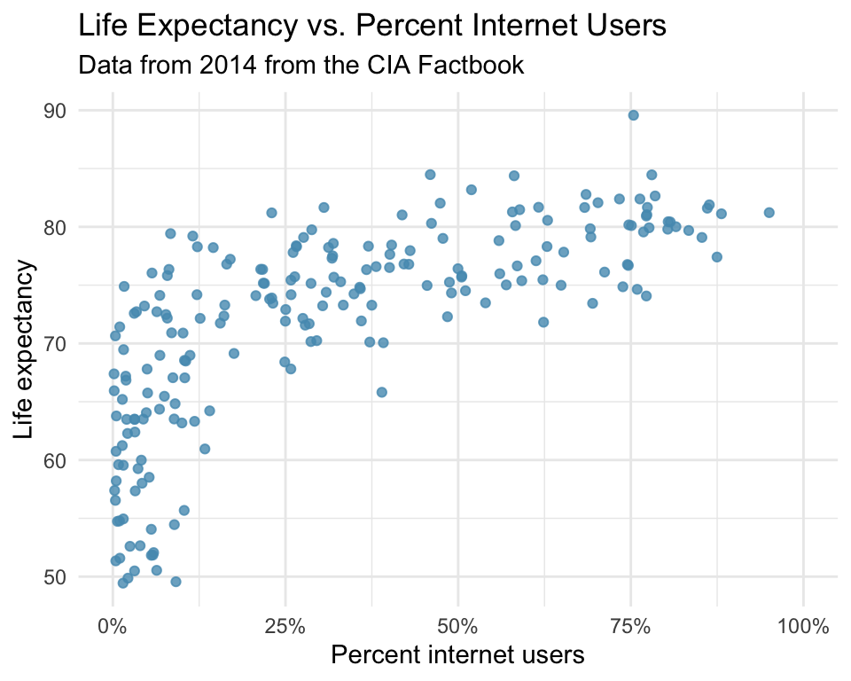

## Questions for Me

- Content questions?
- Course structure questions?
- Programming in `R` questions?

## Drop In `R` Help Session(s)

- Wednesday after class (1:00 - 3:00)
- Thursday office hours (4:00 - 5:00 pm)
- Post to `R` Questions channel in Canvas